# Random Forest

# Install Packages

```r
library(reticulate)
## virtualenv_install("py39bert", "sklearn")
```

# sklearn

- Reference Link: https://machinelearningmastery.com/random-forest-ensemble-in-python/

## Create a classification data

```python
# test classification dataset
import sklearn
print(sklearn.__version__)
```

0.24.2

```python
from sklearn.datasets import make_classification

# define dataset
X, y = make_classification(n_samples=1000, n_features=20, n_informative=15, n_redundant=5, random_state=3)

# summarize the dataset
print(X.shape, y.shape)
```

(1000, 20) (1000,)

```python
print(X[0:2,:])
```

[[ -8.52381793 5.24451077 -12.14967704 -2.92949242 0.99314133 0.67326595 -0.38657932 1.27955683 -0.60712621 3.20807316 0.60504151 -1.38706415 8.92444588 -7.43027595 -2.33653219 1.10358169 0.21547782 1.05057966 0.6975331 0.26076035] [ -0.05916285 -3.54893654 0.28450157 1.46921884 0.77477498 -0.16451756 0.57742115 -3.41655027 1.29000848 -2.33725005 2.64529773 -0.96192472 -0.59736558 0.07244451 1.23651815 -2.18227059 2.07976122 2.25695685 1.22878976 -2.35705572]]

```python
print(y[0:10])
```

[0 1 1 1 0 1 1 0 1 0]

## Split

```python
from sklearn.model_selection import train_test_split
import numpy as np
np.random.seed(20220214)
# Split dataset into training set and test set
X_train, X_test, y_train, y_test = train_test_split(X, y, test_size=0.3)
# 70% training and 30% test
```

## Training

```python
#Import Random Forest Model
from sklearn.ensemble import RandomForestClassifier

#Create a Gaussian Classifier
clf=RandomForestClassifier(n_estimators=1000, criterion="entropy", bootstrap=True, max_features='sqrt')

#Train the model using the training sets y_pred=clf.predict(X_test)
clf.fit(X_train,y_train)
```

RandomForestClassifier(criterion=‘entropy’, max_features=‘sqrt’, n_estimators=1000)

```python
y_pred=clf.predict(X_test)
print(y_pred[0:10])
```

[1 1 0 1 1 0 0 1 1 0]

```python
y_prob=clf.predict_proba(X_test)
print(y_prob[0:10, 1])
```

[0.732 0.704 0.39 0.972 0.934 0.197 0.082 0.858 0.981 0.054]

```python
from sklearn import metrics
print("Accuracy of the model: ", metrics.accuracy_score(y_test, y_pred))
```

Accuracy of the model: 0.9066666666666666

```python
print(dir(clf))
```

[output not shown]

```python
print(clf.feature_importances_)
```

[0.04789072 0.04092288 0.02957815 0.03375616 0.04029592 0.14107694 0.09277075 0.04715679 0.05833594 0.0358099 0.10180679 0.03736681 0.03726705 0.02448571 0.0329265 0.02489695 0.03271667 0.03790507 0.04245479 0.06057948]

## AUC

```python
from sklearn.metrics import roc_auc_score

roc_value = roc_auc_score(y_test, y_prob[:,1])
print(roc_value)
```

0.9700208898173253

```python
import matplotlib.pyplot as plt
from sklearn import metrics
metrics.plot_roc_curve(clf, X_test, y_test)
```

<sklearn.metrics._plot.roc_curve.RocCurveDisplay object at 0x7f93394d1580>

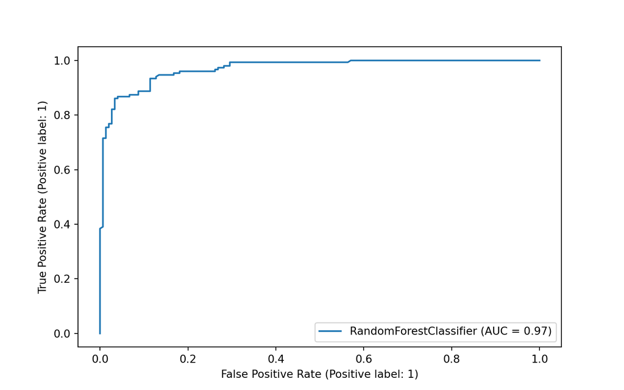

```python
plt.show()
```

## Feature Importance

```python
import pandas as pd
#feature_imp = pd.series(clf.feature_importance_, index = )
```

## Classification

```python
# evaluate random forest algorithm for classification
from numpy import mean
from numpy import std
from sklearn.datasets import make_classification
from sklearn.model_selection import cross_val_score
from sklearn.model_selection import RepeatedStratifiedKFold
from sklearn.ensemble import RandomForestClassifier
# define dataset
X, y = make_classification(n_samples=1000, n_features=20, n_informative=15, n_redundant=5, random_state=3)
# define the model
model = RandomForestClassifier()

# evaluate the model
cv = RepeatedStratifiedKFold(n_splits=10, n_repeats=3, random_state=1)
n_scores = cross_val_score(model, X, y, scoring='accuracy', cv=cv, n_jobs=-1, error_score='raise')
# report performance
print('Accuracy: %.3f (%.3f)' % (mean(n_scores), std(n_scores)))
```

Accuracy: 0.903 (0.022)

## Prediction

```python
# make predictions using random forest for classification
from sklearn.datasets import make_classification
from sklearn.ensemble import RandomForestClassifier
# define dataset
X, y = make_classification(n_samples=1000, n_features=20, n_informative=15, n_redundant=5, random_state=3)
# define the model
model = RandomForestClassifier()
# fit the model on the whole dataset
model.fit(X, y)
# make a single prediction
```

RandomForestClassifier()

```python
row = [[-8.52381793,5.24451077,-12.14967704,-2.92949242,0.99314133,0.67326595,-0.38657932,1.27955683,-0.60712621,3.20807316,0.60504151,-1.38706415,8.92444588,-7.43027595,-2.33653219,1.10358169,0.21547782,1.05057966,0.6975331,0.26076035]]
yhat = model.predict(row)
print('Predicted Class: %d' % yhat[0])
```

Predicted Class: 0